# De novo mutational signature extraction from WGS data

S. Spielman

2021

#### Packages and paths

```r
# Load libraries
library(sigfit)
`%>%` <- dplyr::`%>%`

proj_root_path  <- file.path( rprojroot::find_root(rprojroot::has_dir(".git")) )
analysis_path   <- file.path(proj_root_path, "analyses", "mutational-signatures")
plot_path       <- file.path(analysis_path, "plots")


# Path to input data
path_to_input_rds <- file.path(proj_root_path, "scratch", "mutational-signatures", "extraction")

# Path to consine similarity GOF plots
path_to_cosine <- file.path(analysis_path, "plots", "denovo", "extraction")

# Result path
path_to_results <- file.path(analysis_path, "results")
if (!dir.exists(path_to_results)) {
  dir.create(path_to_results, recursive = TRUE)
}

# De novo signatures and exposures list (condensed from sigfit output) file
de_novo_signatures_file <- file.path(path_to_results, "de_novo_signatures.RDS")
de_novo_exposures_file <- file.path(path_to_results, "de_novo_exposures.RDS")

# Load cosmic data from sigfit
data("cosmic_signatures_v3")
cosmic_names <- row.names(cosmic_signatures_v3)
```

First, we need to extract the signatures and exposures from the *de novo* extraction RDS files. We save each into a list `de_novo_signatures` and `de_novo_extractions` separately, and write each list to file.

```r
# Collect the de novo extracted signatures and exposures into a single list each. This takes _a few minutes_ to parse.
# If running in CI, read in lists directly from RDS files. Otherwise, parse to create and save lists.

if (params$is_ci == 1) {
  de_novo_signatures <- readr::read_rds(de_novo_signatures_file)
  de_novo_exposures <- readr::read_rds(de_novo_exposures_file)
} else {

  de_novo_signatures <- list()
  de_novo_exposures <- list()
  for (this_model in c("poisson" , "multinomial"))
  {
    for (this_seed in 1:5){

      this_name <- glue::glue("seed_{this_seed}_model_{this_model}")
      filename <- file.path(path_to_input_rds,
                            glue::glue("{this_name}.RDS"))
      #cat(filename)
      if (file.exists(filename)) {
        fit <- readr::read_rds(filename)
        for (k in 2:5){
          sig_name <- glue::glue("{k}_{this_name}")
          de_novo_signatures[[ sig_name ]] <- sigfit::retrieve_pars(fit[[k]], par = "signatures")
          de_novo_exposures[[ sig_name ]] <- sigfit::retrieve_pars(fit[[k]], par = "exposures")
        }
      }
    }

  }
  # We save these lists to result files
  readr::write_rds(de_novo_signatures, de_novo_signatures_file)
  readr::write_rds(de_novo_exposures, de_novo_exposures_file)
}
```

Goodness-of-fit analysis was implicitly performed by `sigfit` during inference using cosine similarity. Associated elbow plots are in `plots/extraction/`, names for the model and seed. The red-colored dot in these plots represented the selected *k* for the given seed and inference model. Notably, there substantial sensitivity to starting conditions, both seed and model. **Plots below are shown with `poisson` on top, `multinomial` on bottom**

```r
show_gof_plots <- function(seed)
{
    seed_plots <- c( file.path(path_to_cosine, glue::glue("seed_{seed}_model_poisson.png")),
                     file.path(path_to_cosine, glue::glue("seed_{seed}_model_multinomial.png"))
                   )
    knitr::include_graphics(seed_plots)
}
```

**Seed 1**

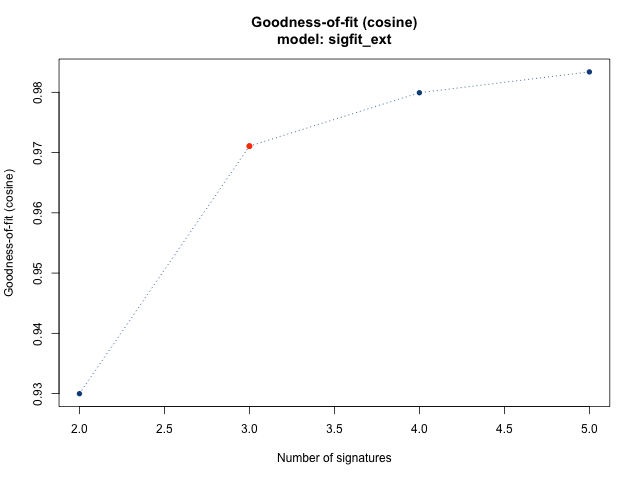

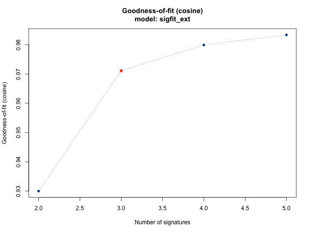

```r
show_gof_plots(1)
```

**Seed 2**

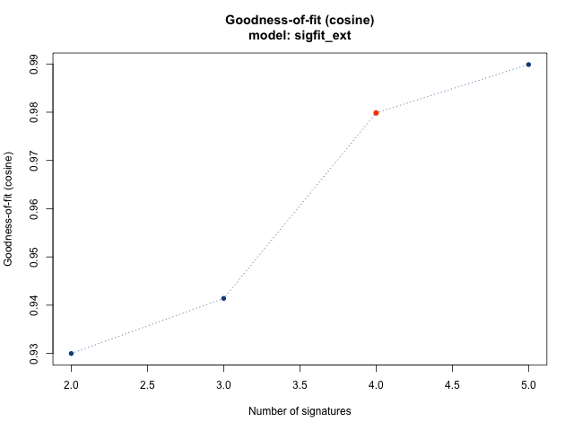

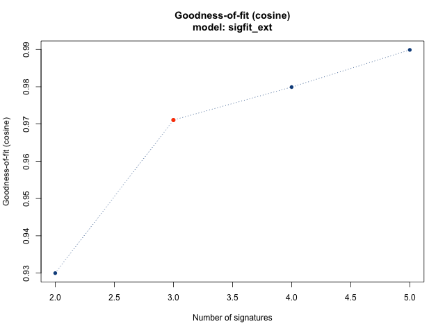

```r
show_gof_plots(2)
```

**Seed 3**

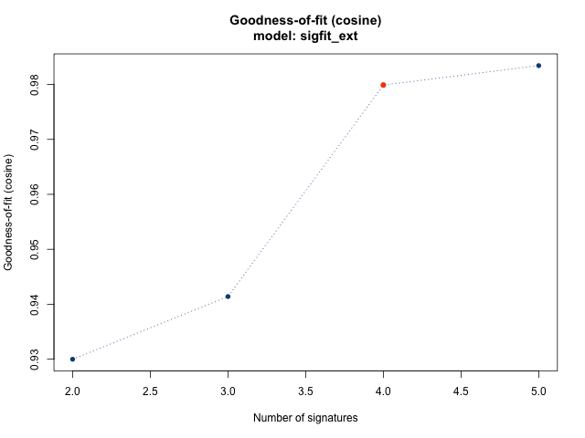

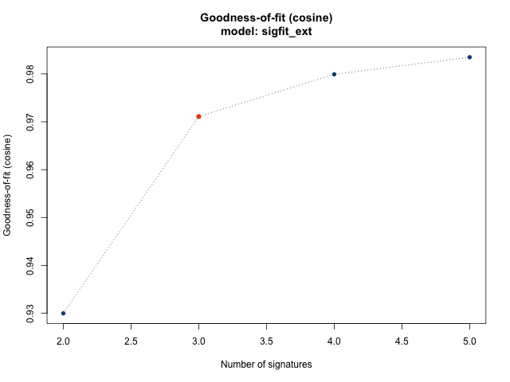

```r
show_gof_plots(3)
```

**Seed 4**

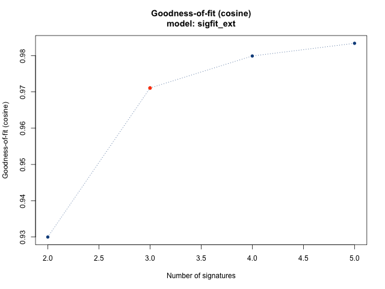

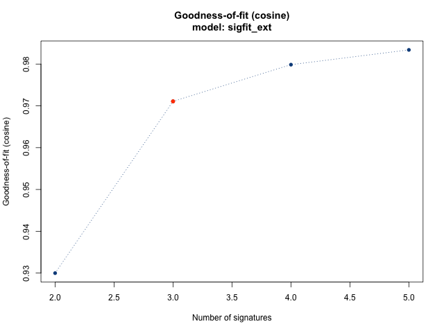

```r
show_gof_plots(4)
```

**Seed 5**

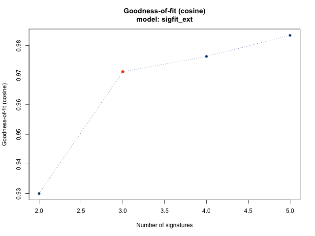

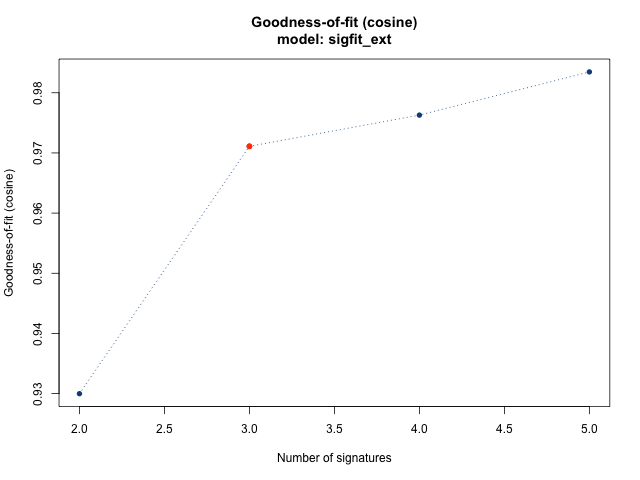

```r
show_gof_plots(5)
```

This tibble collects info from the above images:

```r
gof <- tibble::tribble(
  ~model,     ~seed,      ~best_k,
  #-----------------
  "poisson",1,3,
  "multinomial",1,3,
  "poisson",2,4,
  "multinomial",2,3,
  "poisson",3,4,
  "multinomial",3,3,
  "poisson",4,3,
  "multinomial",4,3,
  "poisson",5,3,
  "multinomial",5,3
)
```

Now, we can determine which signatures were extracted and map back to COSMIC names using cosine similarity to determine matching signatures:

```r
# Will find the COSMIC equivalent using cosine similarity
map_match <- function(x) {
  sort( # Can sort since we just want to see cosmic matches
    as.numeric( # none of this "optimal assigment ==> 1" business
      # match_signatures is a sigfit function for cosine similarity
      match_signatures(x, cosmic_signatures_v3)
    )
  )
}

purrr::map(de_novo_signatures, map_match) -> cosmic_matches
```

Now, we create a table of results for which COSMIC SBS signatures were extracted. **Full results for each combination of k, model, and random seed:**

```r
tibble::tibble(
  name = names(cosmic_matches),
  cosmic_sig_index = unname(cosmic_matches[1:length(cosmic_matches)])
) %>%
  tidyr::unnest(cosmic_sig_index) %>%
  dplyr::mutate(cosmic_sig = cosmic_names[cosmic_sig_index]) -> unnested_sigs

unnested_sigs %>%
  dplyr::group_by(name) %>%
  dplyr::summarize(cosmic_sigs = toString(cosmic_sig)) %>%
  dplyr::mutate(cosmic_sigs = stringr::str_replace_all(cosmic_sigs, "SBS", "")) %>%
  dplyr::mutate(seed  = stringr::str_extract(name, "_\\d_"),
                seed  = stringr::str_replace_all(seed, "_", ""),
                k     = stringr::str_extract(name, "^\\d"),
                model = stringr::str_extract(name, "[a-z]+$")) %>%
  dplyr::select(-name) -> full_sigs

full_sigs %>%
  tidyr::spread(seed, cosmic_sigs) %>%
  knitr::kable()
```

| k | model | 1 | 2 | 3 | 4 | 5 |
| --- | --- | --- | --- | --- | --- | --- |
| 2 | multinomial | 5, 15 | 5, 15 | 5, 15 | 5, 15 | 5, 15 |
| 2 | poisson | 5, 15 | 5, 15 | 5, 15 | 5, 15 | 5, 15 |
| 3 | multinomial | 15, 40, 42 | 15, 40, 42 | 15, 40, 42 | 15, 40, 42 | 15, 40, 42 |
| 3 | poisson | 15, 40, 42 | 5, 11, 15 | 5, 11, 15 | 15, 40, 42 | 15, 40, 42 |
| 4 | multinomial | 14, 15, 23, 40 | 14, 15, 23, 40 | 14, 15, 23, 40 | 14, 15, 23, 40 | 15, 26, 40, 42 |
| 4 | poisson | 14, 15, 23, 40 | 14, 15, 23, 40 | 14, 15, 23, 40 | 14, 15, 23, 40 | 15, 26, 40, 42 |
| 5 | multinomial | 14, 15, 23, 26, 40 | 1, 3, 14, 15, 23 | 14, 15, 23, 26, 40 | 14, 15, 23, 26, 40 | 14, 15, 23, 26, 40 |
| 5 | poisson | 14, 15, 23, 26, 40 | 1, 3, 14, 15, 23 | 14, 15, 23, 26, 40 | 14, 15, 23, 26, 40 | 14, 15, 23, 26, 40 |

```r
gof %>%
  dplyr::rename(k = best_k) %>%
  dplyr::mutate(k = as.character(k), seed = as.character(seed)) %>%
  dplyr::left_join(full_sigs) %>%
  dplyr::filter(model == "poisson") %>%
  dplyr::select(-model) %>%
  dplyr::distinct() %>%
  knitr::kable()
```

| seed | k | cosmic_sigs |
| --- | --- | --- |
| 1 | 3 | 15, 40, 42 |
| 2 | 4 | 14, 15, 23, 40 |
| 3 | 4 | 14, 15, 23, 40 |
| 4 | 3 | 15, 40, 42 |
| 5 | 3 | 15, 40, 42 |

Clearly, this analysis is extremely sensitive to starting conditions. Even so, we see a few repeated SBS signatures coming up:

- **[SBS14](https://cancer.sanger.ac.uk/signatures/sbs/sbs14/)** “is one of seven mutational signatures associated with defective DNA mismatch repair and microsatellite instability (MSI) and is often found in the same samples as other MSI associated signatures: SBS6, SBS15, SBS20, SBS21, SBS26 and SBS44.”
- **[SBS15](https://cancer.sanger.ac.uk/signatures/sbs/sbs15/)** “is one of seven mutational signatures associated with defective DNA mismatch repair and microsatellite instability (MSI) and is often found in the same samples as other MSI associated signatures: SBS6, SBS14, SBS20, SBS21, SBS26 and SBS44.”
- [SBS23](https://cancer.sanger.ac.uk/signatures/sbs/sbs23/) has unknown aetiology.
- [SBS40](https://cancer.sanger.ac.uk/signatures/sbs/sbs40/) is correlated with age (not of clear relevance to pediatric tumors).
- [SBS42](https://cancer.sanger.ac.uk/signatures/sbs/sbs42/) is correlated with occupational exposure to haloalkanes (seems unlikely to be relevant for pediatric tumors?).

**The two bolded** signatures are commonly associated with one another due to putative shared mechanisms of “defective DNA mismatch repair and microsatellite instability (MSI).”